# Streamgraph Usgae

Jie Zou

2022-05-11

## My Thoughts

The first time that I’ve heard about Stream-graph was in 608 class where we were doing live coding demo to figure out how to use d3 to achieve plotting data in the webpage few days ago. I was confused at that time because compared to other intuitive graphs, stream-graph was not easy to interpret. I understand that different colors shown represented distinct categories. Then, what about the squiggly shape? What about the width of each category? Meanwhile, I also wondered why we need to use stream-graph and when the situation is where stream-graph has advantages over other plots and how to make a stream-graph in R.

By carrying these questions, I started doing some general research about it and find that it is nothing more than a basic **stacked area chart**, with fancier design and presentation. It shows the **changes in a numeric variable against another numeric variable**, in which I would say that it shows some relationships between x-axis and y-axis. Moreover, instead of study individual group using stream-graph, it is better to use it while studying **relative proportions of the whole**. According to [data to viz](https://www.data-to-viz.com/graph/streamgraph.html), *“it is very hard to substract the height of other groups at each time point”.*

# Make A Stream Graph

### Data

**only 1 missing value, it can be filtered out**

[output not shown]

[output cut: 113 more lines]

[output not shown]

**Data Before Reshape**

[output not shown]

[output cut: 62 more lines]

**Data After Reshape**

```
##                  Country.Name Country.Code year         gdp
## 1 Africa Eastern and Southern          AFE 1960 19313106302
## 2  Africa Western and Central          AFW 1960 10404280784
## 3                   Australia          AUS 1960 18606786874
## 4                     Austria          AUT 1960  6592693841
## 5                     Burundi          BDI 1960   195999990
## 6                     Belgium          BEL 1960 11658722591
```

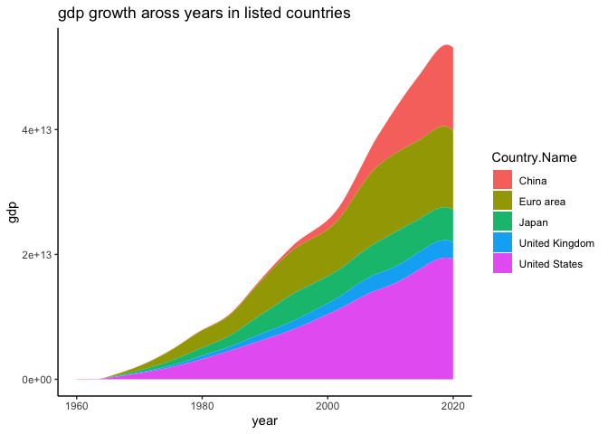

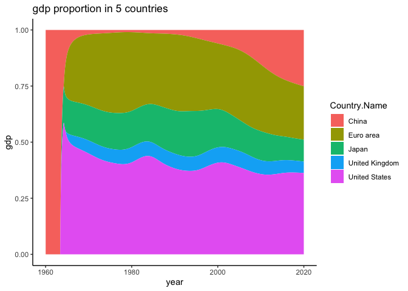